# Índice de impacto al calentamiento global

#### Correlaciones

```r
R = cor(data[,col_numeric],use="complete.obs")
det(R)
```

```
## [1] -1.195223e-45
```

El determinante nos da negativo, nos puede indicar un problema con nuestras variables, ¿Qué nos dice nuestra covarianza?

```r
S = cov(data[,col_numeric],use="complete.obs")
det(S)
```

```
## [1] -6.947407e+103
```

El determinante de nuestra matriz de covarianza indica que tenemos una correlación perfecta en alguna de nuestras variables, podríamos creer que se trata de las variables de población urbana y población rural debido que son complementarías. Quitaremos alguna de las dos:

```r
# Retiramos población rural
R = cor(data[,col_numeric[-3]],use="complete.obs") #Quitamos población urbana
det(R)
```

```
## [1] 8.40022e-15
```

Ahora podemos proseguir, lamentablemente contamos con variables altamente correladas después de realizar la limpieza de variables, pero por lo menos al no tener una matriz singular, ahora podemos obtener los autovalores y autovector a través de la inversa de la matriz.

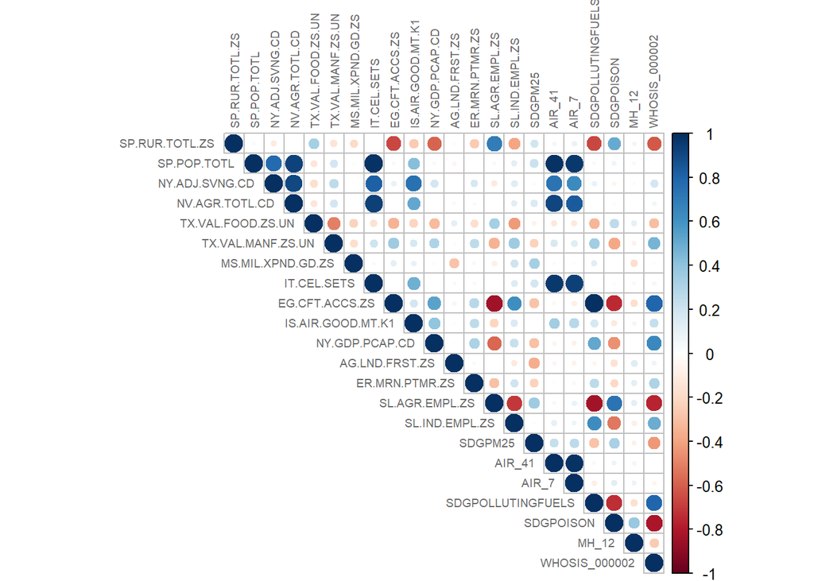

```r
# Quitamos de nuestros ínidice la variable de población urbana defintivamente
col_numeric = col_numeric[-3]

# ¿Correlación entre variables?
corrplot(R, type = "upper", tl.col="#666666", tl.cex = .6)
```

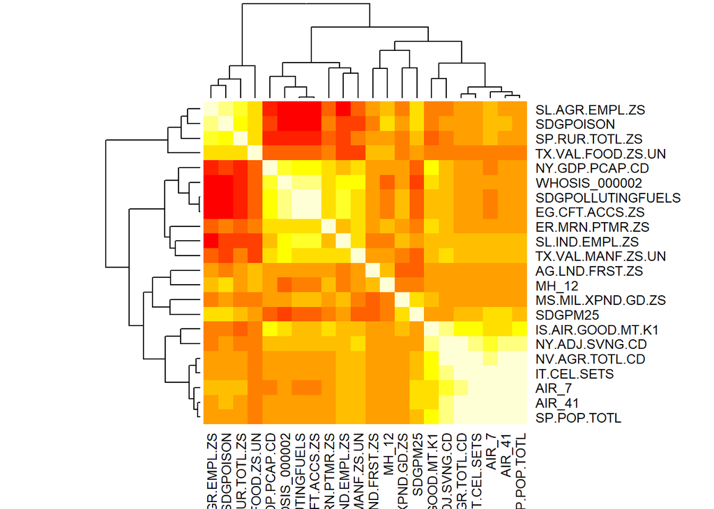

```r
heatmap(R, symm = TRUE)
```

[figure not shown]

```r
# Aunque no es fácil percibir las relaciones con ese tamaño, podemos observar algunos patrones.
pairs(data[,col_numeric],  pch=20, col = data$region)
```

Se observan algunas correlaciones fuertes entre variables, por ejemplo:

- Una correlación positiva entre la expectativa de vida sana y el porcentaje de combustible renovable que se usa respecto al total de energía.
- Una correlación positiva entre la calidad del aire, y la cantidad de población.
- Una correlación entre las emisiones de contaminantes por combustibles y la expectativa de vida.

Y otras que parecen a primera vista un poco extrañas como:

- Una correlación positiva entre el número de personas que usan el móvil y la calidad del aire.

También podemos observar relaciones lineales, cuadráticas y logarítmicas entre variables de forma muy clara, algunas son:

- Empleo industrial - Empleo en agricultura
- Expectativa de vida - Envenenamiento por contaminación
- Expectativa de vida - Exposición a aíre contaminado

Ahora intentaremos visualizar las relaciones múltiples entre nuestras variables, obteniendo la matriz inversa de nuestra matriz de correlaciones.

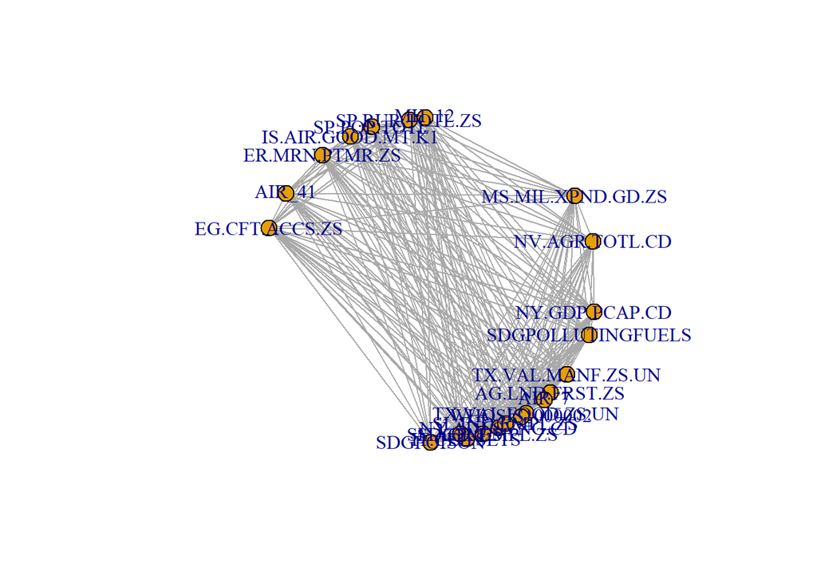

```r
iR <- solve(R)
igraph.f<-graph.adjacency(iR, weighted=TRUE, mode="lower", diag=F)
plot.igraph(igraph.f, edge.width=1,vertex.size=10)
```

Parece que la información no es muy clara, pero nos damos una idea de las múltiples relaciones existentes.

##### Variabilidad

```r
S = cov(data[,col_numeric],use="complete.obs")

det(S)
```

```
## [1] 6.393307e+131
```

```r
sum(diag(S))
```

```
## [1] 4.355993e+22
```

Por lo que podemos observar que la variabilidad de las unidades es amplia, y tendremos que realizar un escalado en nuestros datos.

##### Normalidad

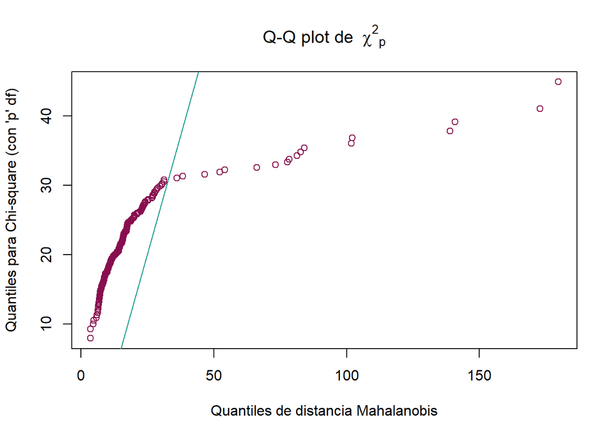

```r
X <- as.matrix(data[,col_numeric])
n <- dim(data[,col_numeric])[1]
p <- dim(data[,col_numeric])[2]

muhat = colMeans(X)
# Añadimos una tolerencia ya que al ser muy cercanas a 0, la interpreta como matriz singular
dM2 <- mahalanobis(X, muhat, S, tol=1e-29)

qqplot(dM2, qchisq(ppoints(n), df = p), xlab="Quantiles de distancia Mahalanobis",
       ylab="Quantiles para Chi-square (con 'p' df)", pch=21, col="#880E4F",
       main = expression("Q-Q plot de" ~~ {chi^2}[p]))
qqline(dM2, distribution = function(q) qchisq(q, df = p), col = "#009688")
```

Debido al comportamiento de nuestras distancias, se puede observar claros Outliers, pero además podríamos decir que no sigue una normal.

#### Outliers

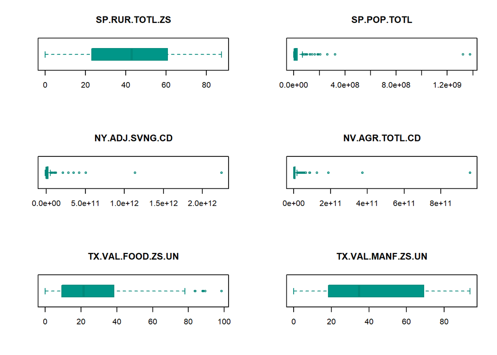

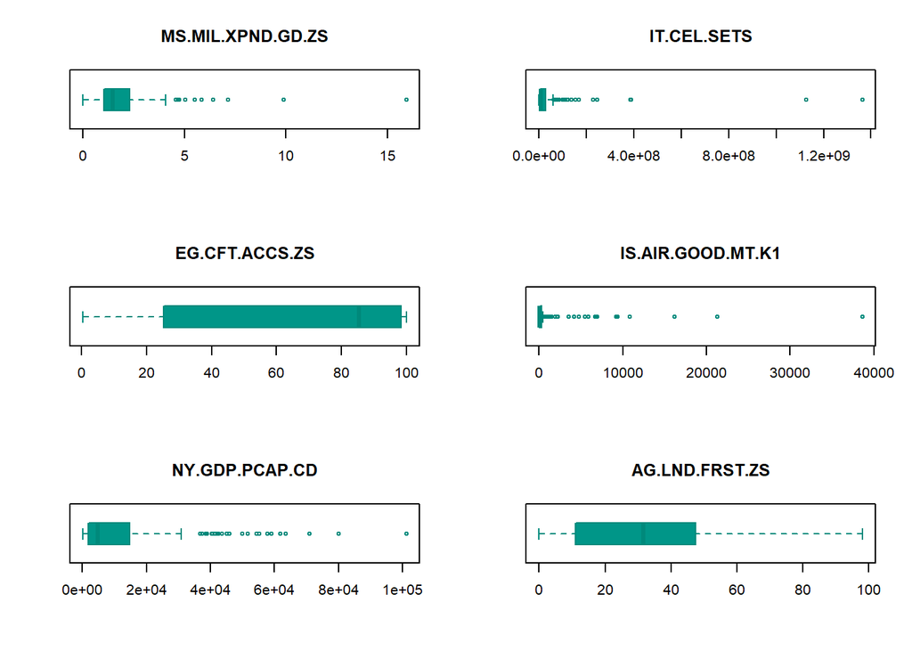

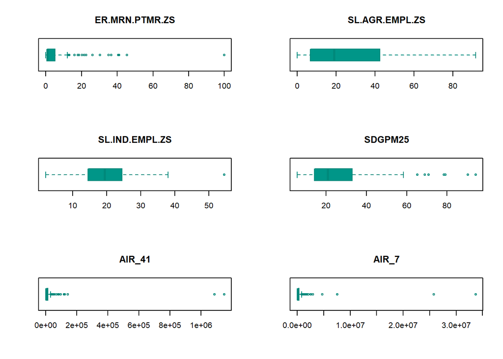

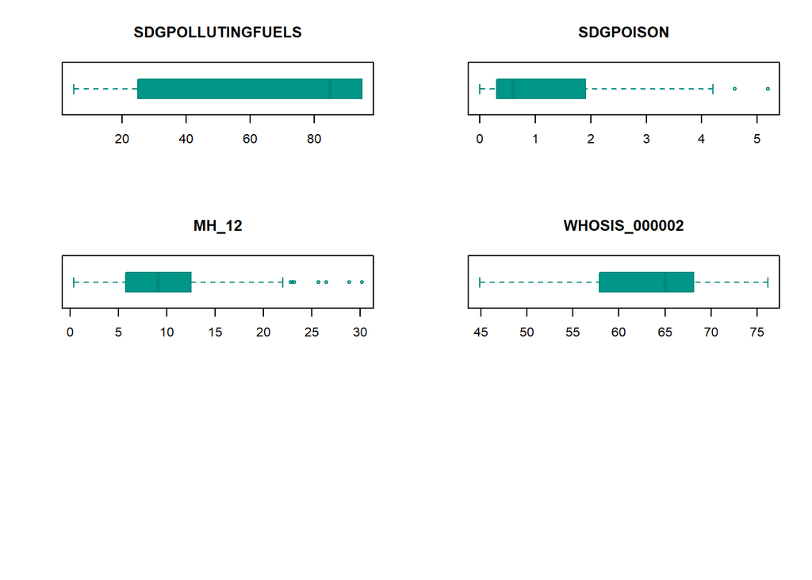

```r
par(mfrow=c(3,2))

invisible(sapply(col_numeric, function(x) {
  boxplot(data[,x], main= x, col = "#009688", border = "#00897B", horizontal = T)}))
```

Exploraremos algunos aspectos buscando respuestas respecto al origen de estos Outliers.Ya que todos los outliers parecen estar por encima del bigote superior (y ninguno inferior), obtendremos las datos que estén por encima del valor del tercer cuartil, sumando 1.5 veces el valor de Rango Intercuartílico.

**¿Son China e India algunos de los países con Outliers Población Total?**

```r
qnt <- quantile(data$SP.POP.TOTL, probs=c(.25, .75))
outliers <- data[data$SP.POP.TOTL > qnt[2] + 1.5*IQR(data$SP.POP.TOTL),c("country","SP.POP.TOTL")]
outliers[order(outliers$SP.POP.TOTL, decreasing = T),]
```

```
##                country SP.POP.TOTL
## 36               China  1378665000
## 78               India  1324171354
## 186      United States   323071342
## 79           Indonesia   261115456
## 24              Brazil   207652865
## 133           Pakistan   193203476
## 128            Nigeria   185989640
## 14          Bangladesh   162951560
## 144 Russian Federation   144342396
## 112             Mexico   127540423
## 86               Japan   126994511
## 139        Philippines   103320222
## 59            Ethiopia   102403196
## 53    Egypt, Arab Rep.    95688681
## 191            Vietnam    94569072
## 66             Germany    82348669
## 80  Iran, Islamic Rep.    80277428
## 179             Turkey    79512426
## 39    Congo, Dem. Rep.    78736153
## 173           Thailand    68863514
```

Sí, y todos los países obtenidos están en la lista de los 20 países más poblados del mundo.

**¿Es posible la exsitencia de Outliers tan pronunciada en valor agregado total en Agricultura (*NV.AGR.TOTL.CD*)?**

```r
qnt <- quantile(data$NV.AGR.TOTL.CD, probs=c(.25, .75))
outliers <- data[data$NV.AGR.TOTL.CD > qnt[2] + 1.5*IQR(data$NV.AGR.TOTL.CD),c("country","region","NV.AGR.TOTL.CD")]
outliers[order(outliers$NV.AGR.TOTL.CD, decreasing = T),]
```

```
##                country                region NV.AGR.TOTL.CD
## 36               China       Western Pacific   958278275265
## 78               India       South-East Asia   372190852855
## 186      United States              Americas   188937833000
## 79           Indonesia       South-East Asia   125605406684
## 24              Brazil              Americas    87891946116
## 128            Nigeria                Africa    84908054292
## 133           Pakistan Eastern Mediterranean    64690228085
## 86               Japan       Western Pacific    56932943210
## 179             Turkey                Europe    53410357273
## 144 Russian Federation                Europe    49296812986
## 80  Iran, Islamic Rep.                Africa    40378317245
## 53    Egypt, Arab Rep.       Western Pacific    39183328652
## 112             Mexico              Americas    36102367540
## 62              France                Europe    35754141626
```

[output cut: 16 more lines]

Parecen lógico debido a su tamaño territorial y cantidad de población, siendo además China e India los que tiene mayor valor agregado, lo que se puede observar.

**¿Es posible que alguien tenga casi el 100 de mercado de exportación de alimientos (*TX.VAL.FOOD.ZS.UN*)?**

```r
qnt <- quantile(data$TX.VAL.FOOD.ZS.UN, probs=c(.25, .75))
outliers <- data[data$TX.VAL.FOOD.ZS.UN > qnt[2] + 1.5*IQR(data$TX.VAL.FOOD.ZS.UN),c("country","region","TX.VAL.FOOD.ZS.UN")]
outliers[order(outliers$TX.VAL.FOOD.ZS.UN, decreasing = T),]
```

```
##                            country          region TX.VAL.FOOD.ZS.UN
## 106                       Maldives South-East Asia          98.55777
## 152                     Seychelles          Africa          89.46247
## 148          Sao Tome and Principe          Africa          88.44718
## 165 St. Vincent and the Grenadines          Europe          87.96885
## 59                        Ethiopia          Africa          83.82269
## 104                         Malawi          Africa          83.72755
## 29                      Cabo Verde          Africa          83.57011
```

En este caso resulta complicado corroborar los datos, no fue posible encontrar fuentes de datos con las cuales contrastar dichos valores, pero a primera impresión *parecen probables errores*, en algunos derivados de la imputación a la mediana.

**¿Es posibile que algún país tenga caso el 100% de sus aguas marinas como protegidas (*ER.MRN.PTMR.ZS*)?**

```r
qnt <- quantile(data$ER.MRN.PTMR.ZS, probs=c(.25, .75))
outliers <- data[data$ER.MRN.PTMR.ZS > qnt[2] + 1.5*IQR(data$ER.MRN.PTMR.ZS),c("country","region","ER.MRN.PTMR.ZS")]
#Obtenemos los primero 4 para consultar los países con más áreas marinas protegidas.
outliers[order(outliers$ER.MRN.PTMR.ZS, decreasing= T),][1:4,]
```

```
##           country          region ER.MRN.PTMR.ZS
## 156      Slovenia          Europe      100.00000
## 66        Germany          Europe       45.35655
## 186 United States        Americas       41.08292
## 9       Australia Western Pacific       40.65344
```

Eslovenia, cuenta con un pequeño territorio marino, con una protección del 99.86%, por lo que se puede confirmar que el dato es verdadero. Fuente: http://www.mpatlas.org/region/country/SVN/

### Análisis multivariante

En esta sección utilizaremos algunas herramientas de análisis multivariante, para llegar a nuestro objetivo.

Primeramente transformamos a forma logarítmica algunas variables que debido a su población inmensa o tamaño territorial, fuera de lo común, tiene valores outliers:

```r
data_pca = data[,col_numeric]
data_pca[col_numeric[c(2,3,6,7,9,10,11,13,14,15,16,18,19)]] = log(data[,col_numeric[c(2,3,6,7,9,10,11,13,14,15,16,18,19)]])
```

#### PCA

Aplicamos un análisis de componentes principales, centramos a cero y escalamos.

```r
pca = prcomp(data[,col_numeric], center=TRUE, scale=TRUE)

summary(pca)
```

```
## Importance of components:
##                           PC1    PC2     PC3     PC4     PC5     PC6
## Standard deviation     2.5537 2.3974 1.39527 1.15049 1.06596 0.99636
## Proportion of Variance 0.2964 0.2612 0.08849 0.06017 0.05165 0.04512
## Cumulative Proportion  0.2964 0.5577 0.64615 0.70632 0.75797 0.80309
##                            PC7     PC8     PC9    PC10    PC11   PC12
## Standard deviation     0.88769 0.85749 0.77563 0.72008 0.61534 0.5801
## Proportion of Variance 0.03582 0.03342 0.02735 0.02357 0.01721 0.0153
## Cumulative Proportion  0.83891 0.87233 0.89968 0.92325 0.94046 0.9557
##                           PC13    PC14    PC15    PC16    PC17    PC18
## Standard deviation     0.54024 0.46019 0.42015 0.37103 0.30830 0.17845
## Proportion of Variance 0.01327 0.00963 0.00802 0.00626 0.00432 0.00145
## Cumulative Proportion  0.96902 0.97865 0.98667 0.99293 0.99725 0.99870
##                           PC19    PC20    PC21    PC22
## Standard deviation     0.13364 0.06922 0.06144 0.04775
## Proportion of Variance 0.00081 0.00022 0.00017 0.00010
## Cumulative Proportion  0.99951 0.99972 0.99990 1.00000
```

Podemos observar que las primeras dos componentes describen más del 50% de nuestra varianza total de los datos, utilizaremos in screeplot y el criterio de codo para tomar el número de componentes:

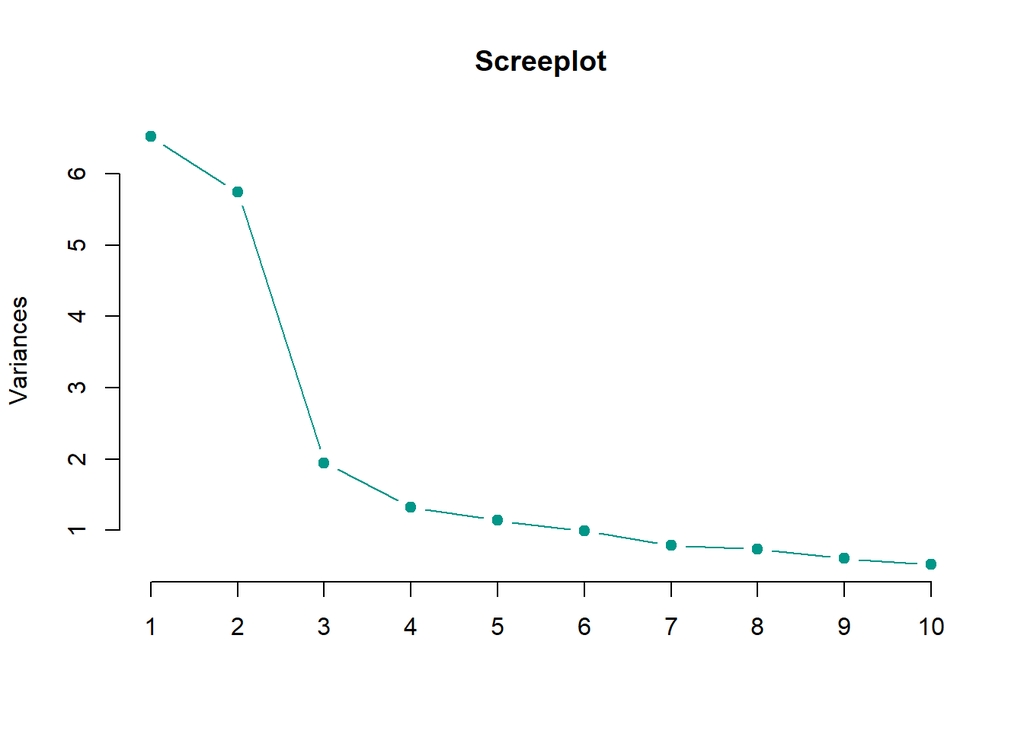

```r
screeplot(pca,main="Screeplot",col="#009688",type="lines",pch=19)
```

Se observa que tomar los primeros 3 componentes sería el más indicado, más necesitamos comprender que está describiendo cada componente, para poder transmitir de forma clara nuestro índice.

##### Descripción de componentes principales

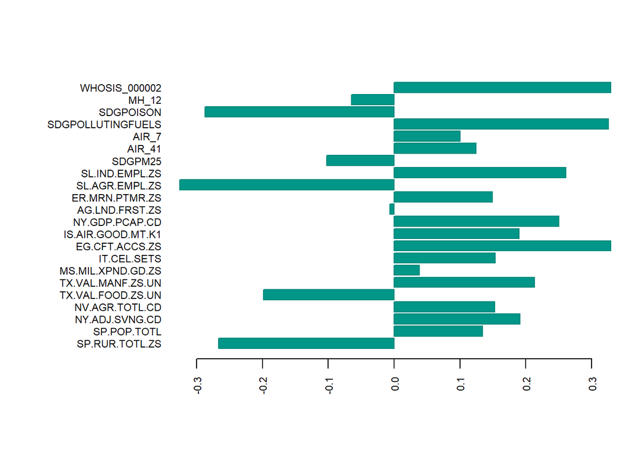

```r
par(mar=c(5,10,4,1))
barplot(pca$rotation[,1], las=2, col="#009688", border = "#00897B", cex.names= .7, cex.axis=.7, horiz=TRUE)
```

Se puede observar que un cantidad considerable de variables que fueron incluidas con el objetivo de dar un sentido de disminución de calidad o expectativa de vida, tomaron un sentido distinto aquí, ya que puede ser interpretadas por la relación que guardan con variables del mismo signo como mitigadores.

A esta componente le llamaremos **Impacto o aporte al calentamiento global**.

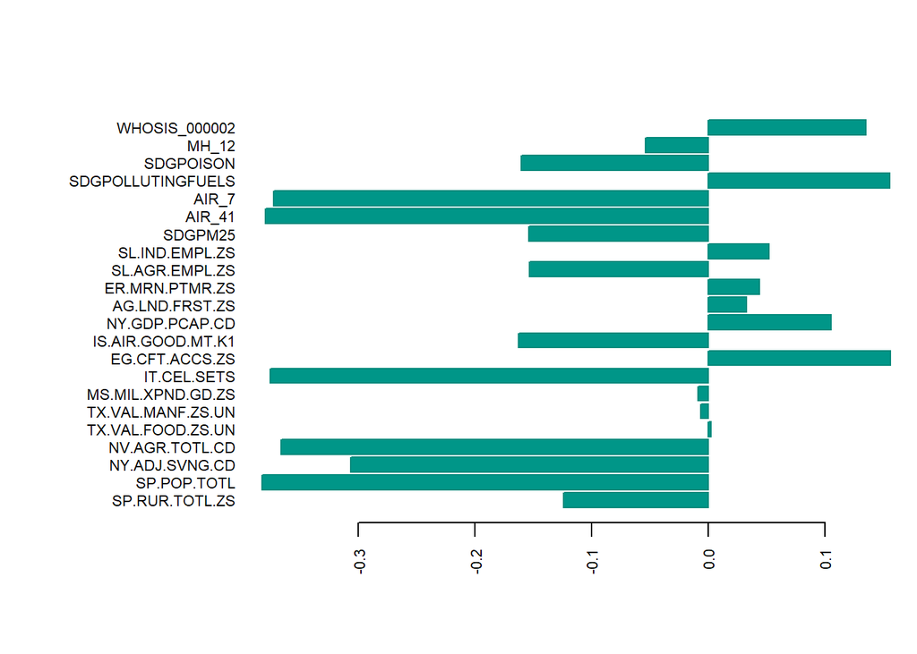

```r
par(mar=c(5,10,4,1))
barplot(pca$rotation[,2], las=2, col="#009688", border = "#00897B", cex.names= .7, cex.axis=.7, horiz=TRUE)
```

En esta nueva componente se observa un agrupamiento distinto, por un lado vemos expectativa de vida sana, dependencia de tecnologías y combustible limpios, PIB, porcentaje de áreas marinas protegidas, acceso a tecnologías limpias para cocinas y exportación de comida.

Este componente es más complicado de interpretar, pero sí tomamos en cuenta las dimensiones de las variables, podríamos decir que se trata de un componente que toma más en cuenta lo económico, por un lado las alternativas que disminuyen en calentamiento global, así como resultantes de la actividad económica, y por el otro efectos, **población** y actividades económicas que aportan más al calentamiento global.

A esta componente le llamaremos **Desarrollo sostenible - Economia** .

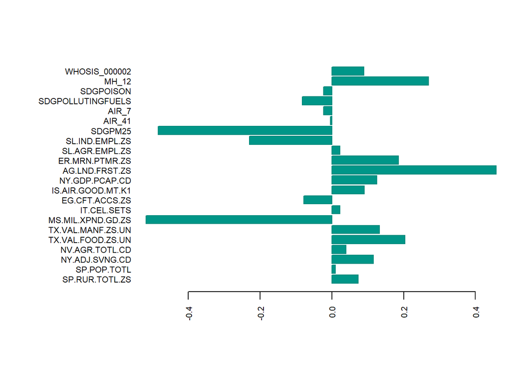

```r
par(mar=c(5,10,4,1))
barplot(pca$rotation[,3], las=2, col="#009688" , border = "#00897B", cex.names= .7, cex.axis=.7, horiz=TRUE)
```

Este factor no es fácil de interpretar, sus variables no tiene mucho en común para nuestro objetivo. La variable con mayor dimensión es el porcentaje de PIB asociado a militarización, una variable que añadida como experimental o complementaria, por lo que **vamos a descartar esta componente como parte de la descripción de nuestro índice**.

¿Cómo están de dispersos los datos?

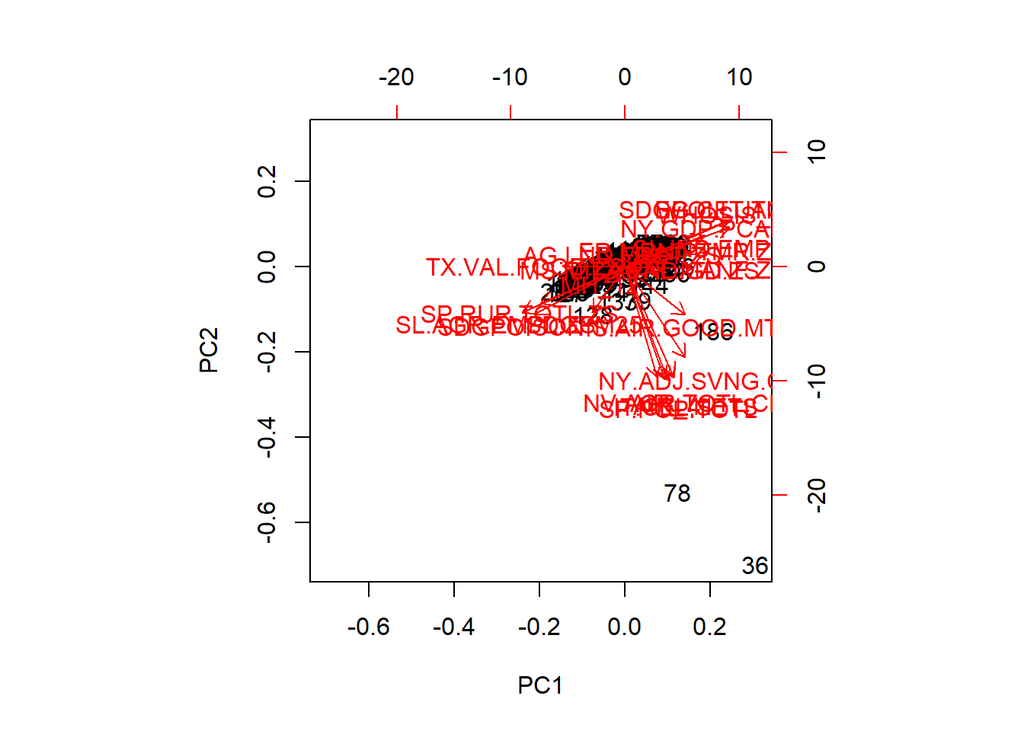

```r
biplot(pca)
```

Parece que tenemos tres países con un comportamiento distinto a la mayoría, todos por aporte de la segunda componente (Economía - Población).

##### Representación del índice

Vamos a visualizar nuestro índice con distintos criterios, buscando encontrar algún insight interesante.

**¿Está nuestro índice asociado por región?**

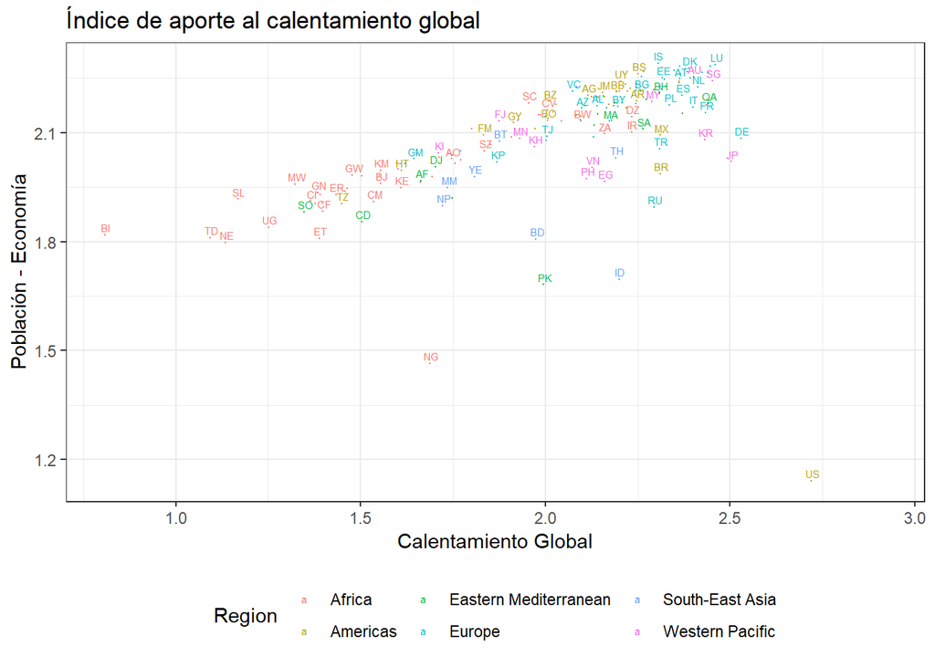

```r
# Añadimos un pequeño constante y ponemos en forma logaritmica para separales un poco.
qplot(log(pca$x[,1]+8),log(pca$x[,2]+8),col=data$region,label=data$iso2c, size=I(.1)) +
  labs(title="Índice de aporte al calentamiento global", x="Calentamiento Global", y="Población - Economía", color="Region") +
  theme_bw() + theme(legend.position="bottom") + geom_text(size=2, hjust=.4, vjust=-.4, check_overlap = TRUE)
```

**¿Están los suicidios relacionados al calentamiento global?**

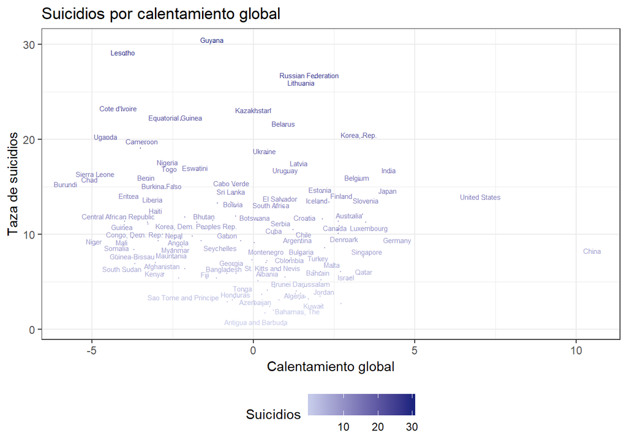

```r
data.frame(z1=pca$x[,1],z2=data_pca$MH_12) %>%
  ggplot(aes(z1,z2,label=data$country,color=data_pca$MH_12)) + geom_point(size=0) +
  labs(title="Suicidios por calentamiento global", x="Calentamiento global", y="Taza de suicidios", color="Suicidios") +
  scale_color_gradient(low="#C5CAE9", high="#1A237E") +
  theme_bw() + theme(legend.position="bottom") + geom_text(size=2, hjust=0.6, vjust=0, check_overlap = TRUE)
```

No parecen tener una relación clara, los datos **no tienen un patrón claro** que nos permita conocer una relación lineal o de otro tipo.

**¿Los países que más aportan al calentamiento global tienen una relación a su PIB?**

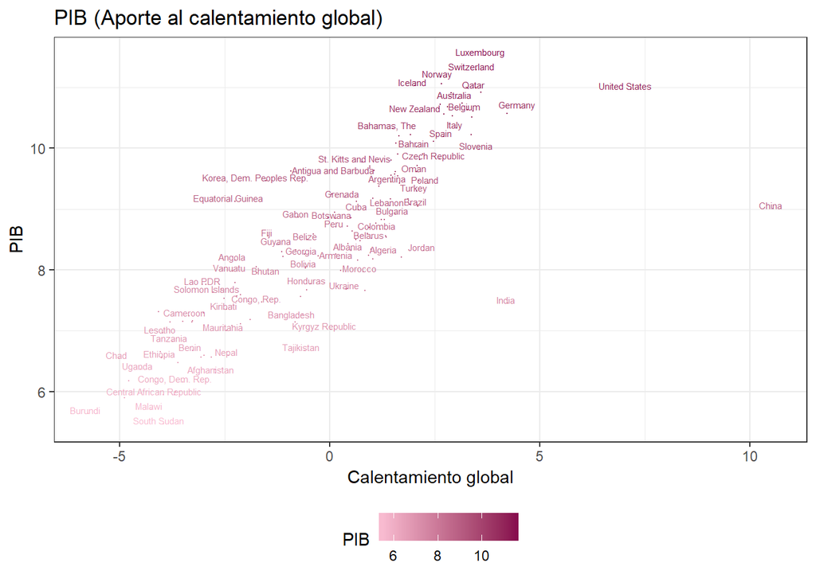

```r
data.frame(z1=pca$x[,1],z2=data_pca$NY.GDP.PCAP.CD) %>%
  ggplot(aes(z1,z2,label=data$country,color=data_pca$NY.GDP.PCAP.CD)) + geom_point(size=0) +
  labs(title="PIB (Aporte al calentamiento global)", x="Calentamiento global", y="PIB", color="PIB") +
  scale_color_gradient(low="#F8BBD0", high="#880E4F") +
  theme_bw() + theme(legend.position="bottom") + geom_text(size=2, hjust=0.6, vjust=0, check_overlap = TRUE)
```

Podría decirse que sí tiene una relación, el patrón de la relación es muy claro, de **tipo lineal**. (Recordando que se realizó una transformación logarítmica sobre las variables, por lo que la relación lineal es en realidad de tipo logarítmica (-1/log(x))).

**¿Las población rural tienen una relación respecto al calentamiento global?**

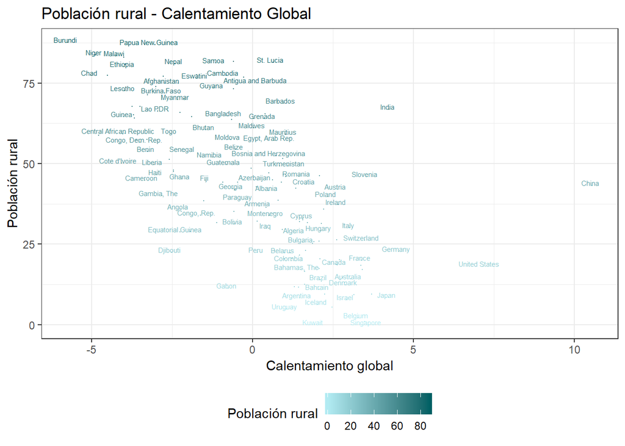

```r
data.frame(z1=pca$x[,1],z2=data_pca$SP.RUR.TOTL.ZS) %>%
  ggplot(aes(z1,z2,label=data$country,color=data_pca$SP.RUR.TOTL.ZS)) + geom_point(size=0) +
  labs(title="Población rural - Calentamiento Global", x="Calentamiento global", y="Población rural", color="Población rural") +
  scale_color_gradient(low="#B2EBF2", high="#006064") +
  theme_bw() + theme(legend.position="bottom") + geom_text(size=2, hjust=0.6, vjust=0, check_overlap = TRUE)
```

No es del todo claro, pero se podría decir que existe una **relación lineal negativa**, que se traduciría como algo que mitiga el calentamiento global.

**¿Tiene relación la inversión en Militarización de un país con el calentamiento Global?**

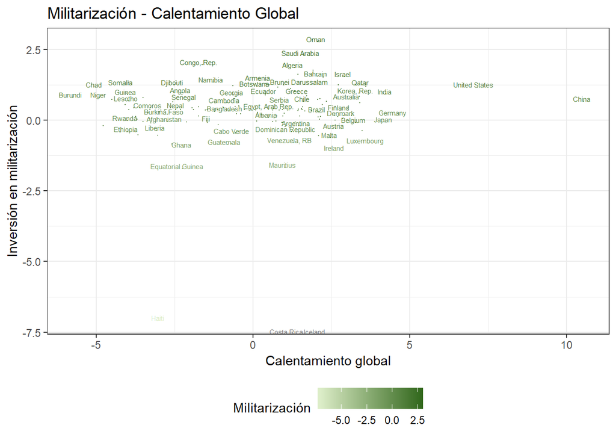

```r
data.frame(z1=pca$x[,1],z2=data_pca$MS.MIL.XPND.GD.ZS) %>%
  ggplot(aes(z1,z2,label=data$country,color=data_pca$MS.MIL.XPND.GD.ZS)) + geom_point(size=0) +
  labs(title="Militarización - Calentamiento Global", x="Calentamiento global", y="Inversión en militarización", color="Militarización") +
  scale_color_gradient(low="#DCEDC8", high="#33691E") +
  theme_bw() + theme(legend.position="bottom") + geom_text(size=2, hjust=0.6, vjust=0, check_overlap = TRUE)
```

A primera vista pareciera que sí tiene una relación lineal, sin embargo debemos recordar que la variable se encuentra transformada logarítmicamente, y que existen valores en 0, que están empujando a los demás valores en el gráfico, si quitamos la transformación **no se observa un patrón claro**.

**Mapa del índice**

```r
# Haciendo match entre nuestros datos y los países de representación en el mapa.
matched <- joinCountryData2Map(data.frame(country=data$country, global=pca$x[,1]), joinCode="NAME", nameJoinColumn="country")
```

```
## 179 codes from your data successfully matched countries in the map
## 5 codes from your data failed to match with a country code in the map
## 64 codes from the map weren't represented in your data
```

```
## You asked for 7 categories, 9 were used due to pretty() classification
```

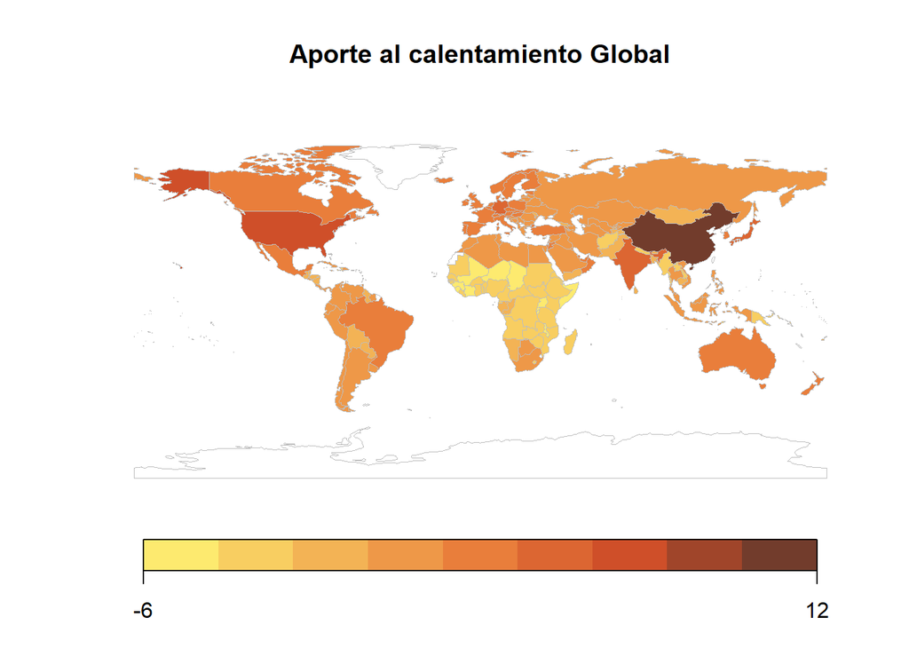

```r
# Plot del mapa
mapCountryData(matched, nameColumnToPlot="global", mapTitle="Aporte al calentamiento Global",
               catMethod = "pretty", colourPalette = c("#FDEA6F","#F3B355","#E97E3B","#CF4F29","#723C2C"))
```

#### Factor Analysis

Ahora utilizaremos un análisis factorial, y compararemos el resultado obtenido a través de componentes principales.

Debido a que el error no es representativo para nosotros, utilizaremos una rotación *varimax* y elegiremos el número de factores de manera intuitiva, esperando que describa lo suficiente nuestras variables.

Utilizaremos sólo dos factores para buscar su interpretación.

```r
data_factor = data[,col_numeric]
data.f <- factanal(data_factor, factors = 2, rotation="varimax", scores="regression", lower = 0.01)
data.f
```

```
##
## Call:
## factanal(x = data_factor, factors = 2, scores = "regression",     rotation = "varimax", lower = 0.01)
##
## Uniquenesses:
##    SP.RUR.TOTL.ZS       SP.POP.TOTL    NY.ADJ.SVNG.CD    NV.AGR.TOTL.CD
##             0.545             0.010             0.376             0.137
## TX.VAL.FOOD.ZS.UN TX.VAL.MANF.ZS.UN MS.MIL.XPND.GD.ZS       IT.CEL.SETS
##             0.855             0.833             0.985             0.022
##    EG.CFT.ACCS.ZS IS.AIR.GOOD.MT.K1    NY.GDP.PCAP.CD    AG.LND.FRST.ZS
##             0.010             0.775             0.715             0.995
##    ER.MRN.PTMR.ZS    SL.AGR.EMPL.ZS    SL.IND.EMPL.ZS           SDGPM25
##             0.923             0.282             0.593             0.872
##            AIR_41             AIR_7 SDGPOLLUTINGFUELS         SDGPOISON
##             0.029             0.066             0.010             0.440
##             MH_12     WHOSIS_000002
##             0.969             0.352
##
## Loadings:
##                   Factor1 Factor2
## SP.RUR.TOTL.ZS            -0.675
## SP.POP.TOTL        0.996
## NY.ADJ.SVNG.CD     0.784
## NV.AGR.TOTL.CD     0.929
## TX.VAL.FOOD.ZS.UN -0.152  -0.349
## TX.VAL.MANF.ZS.UN  0.198   0.358
## MS.MIL.XPND.GD.ZS          0.119
## IT.CEL.SETS        0.989
## EG.CFT.ACCS.ZS             0.996
## IS.AIR.GOOD.MT.K1  0.435   0.189
## NY.GDP.PCAP.CD             0.534
## AG.LND.FRST.ZS
## ER.MRN.PTMR.ZS             0.277
## SL.AGR.EMPL.ZS            -0.848
## SL.IND.EMPL.ZS     0.136   0.623
## SDGPM25            0.206  -0.293
## AIR_41             0.984
## AIR_7              0.962
## SDGPOLLUTINGFUELS          0.996
## SDGPOISON                 -0.748
## MH_12                     -0.172
## WHOSIS_000002              0.804
##
##                Factor1 Factor2
## SS loadings      5.664   5.550
## Proportion Var   0.257   0.252
## Cumulative Var   0.257   0.510
##
## Test of the hypothesis that 2 factors are sufficient.
## The chi square statistic is 1744.86 on 188 degrees of freedom.
## The p-value is 3.83e-250
```

**¿Qué se oberva en su varabilidad única?**

```r
cbind(data.f$loadings, data.f$uniquenesses)
```

```
##                        Factor1      Factor2
## SP.RUR.TOTL.ZS     0.011295908 -0.674500272 0.54512173
## SP.POP.TOTL        0.995883619 -0.036903506 0.01000000
## NY.ADJ.SVNG.CD     0.784290491  0.092454786 0.37633000
## NV.AGR.TOTL.CD     0.929101615  0.003605069 0.13673818
## TX.VAL.FOOD.ZS.UN -0.152186605 -0.348993641 0.85539796
## TX.VAL.MANF.ZS.UN  0.197762968  0.358122973 0.83277076
## MS.MIL.XPND.GD.ZS  0.030559231  0.119381052 0.98495638
## IT.CEL.SETS        0.988862298  0.006045424 0.02211456
## EG.CFT.ACCS.ZS     0.001054629  0.996149539 0.01000000
## IS.AIR.GOOD.MT.K1  0.434829506  0.189421541 0.77513680
## NY.GDP.PCAP.CD    -0.016139876  0.533551756 0.71465423
## AG.LND.FRST.ZS    -0.049588281 -0.052045368 0.99468341
## ER.MRN.PTMR.ZS     0.017756864  0.277367824 0.92316640
## SL.AGR.EMPL.ZS     0.004917133 -0.847644291 0.28161042
## SL.IND.EMPL.ZS     0.136373439  0.623407998 0.59286290
## SDGPM25            0.205871264 -0.292584612 0.87246521
## AIR_41             0.984104549 -0.045493513 0.02946859
## AIR_7              0.962349128 -0.086860895 0.06634050
## SDGPOLLUTINGFUELS  0.000155153  0.995718601 0.01000000
## SDGPOISON          0.041567190 -0.747507845 0.43952717
## MH_12              0.040987744 -0.172358356 0.96905629
## WHOSIS_000002      0.040401001  0.803827155 0.35211142
```

Las variables como lo son *taza de suicidio*, *áreas marinas protegidas* o *exportaciones (alimento y manufactura)*, tienen una variabilidad independiente muy alta, por lo que resultan poco relevantes para los factores.

Ahora vamos a gratificar para intentar realizar una interpretación:

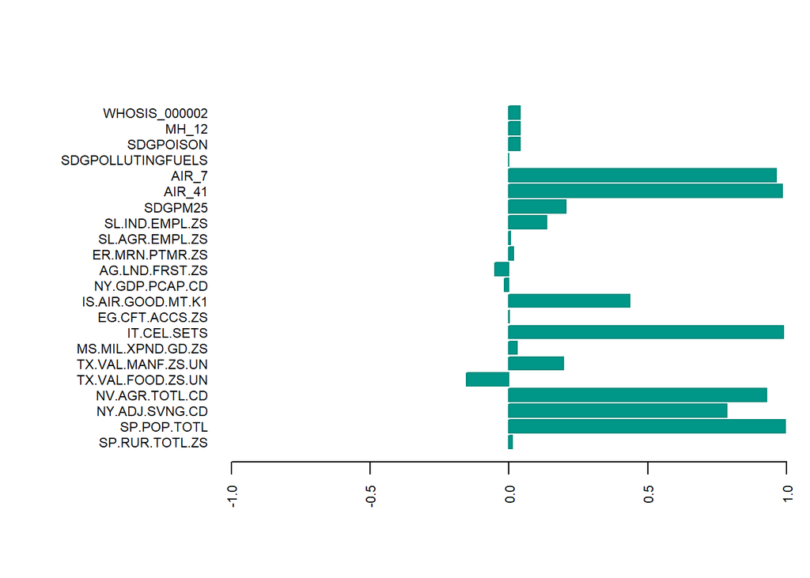

```r
par(mar=c(5,10,4,1))
barplot(data.f$loadings[,1], las=2, col="#009688" , border = "#00897B", cex.names= .7, cex.axis=.7, horiz=TRUE,  xlim = c(-1, 1))
```

Asignarle un nombre es complicado, pero se distingue con claridad la relación antes descrita.

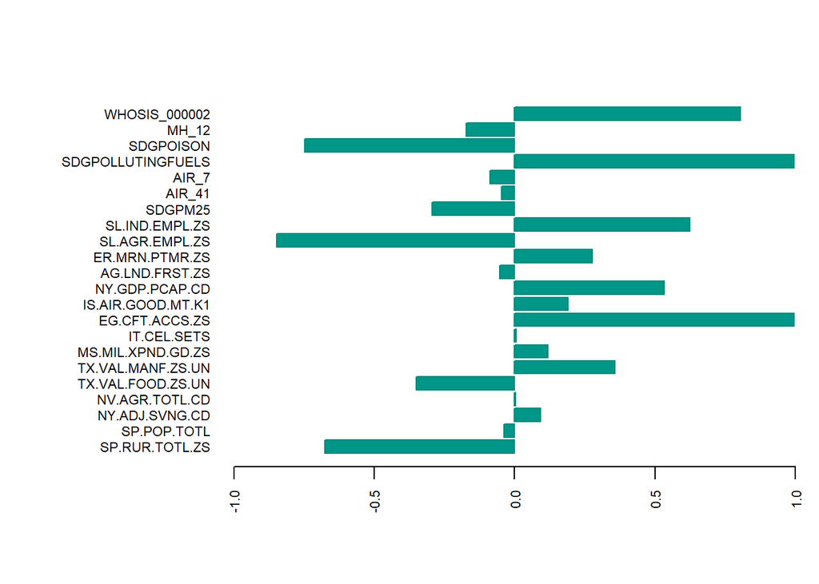

```r
par(mar=c(5,10,4,1))
barplot(data.f$loadings[,2], las=2, col="#009688" , border = "#00897B", cex.names= .7, cex.axis=.7, horiz=TRUE,  xlim = c(-1, 1))
```

### Conclusiones

La calidad de los datos tiene un gran impacto en el uso o creación de modelos, el uso de análisis multivariantes no es la excepción; a pesar de planear de manera estratégica el uso de más de 50 variables en torno a 4 temáticas: *Salud, Economía, Población y Desarrollo Sostenible*, que hemos tomado por su posible relación con el calentamiento global (sesgando el modelo), hemos tenido que desistir a la gran mayoría de ellas por falta de datos (En distintas dimensiones: falta de datos por año, por país, por variable, por región, etc).

El análisis de componentes principales y factores realizado ha dado resultados, sin embargo muchas de las variables al tener alta correlación, describen comportamiento similares, por lo que perdimos mucha riqueza multivariante.

A pesar de no quedar totalmente satisfecho con los resultados de los análisis multivariantes realizados, pudimos obtener un índice que tiene cierta lógica, y que además tomando la primera componente, o el primer factor (respecto a cada análisis), se logra una descripción razonable del aporte al cambio climático.